# Data Analysis

### Read in Data

First, we will read in the data:

```r
#install.packages("here") # BCS changed
library(here)
d <- read.csv(here("data","summarized_data.csv"))
d_save<-d
```

The summarized dataset contains 626 observations, but let’s look at the first handful of rows in the data to see what we’re dealing with:

```r
head(d, n = 5)
```

```
##        subject_ID p_cor_sex p_cor_lang p_cor_age time_mins fin_consent_mins
## 1 01x5706uljd0nog       0.6  0.5833333 0.3333333 26.695100       0.10610000
## 2 050kw45eslh0o3w       0.4  0.5000000 0.3333333 12.619700       1.43655000
## 3 05yokbmjrv9ndze       0.6  0.5833333 0.4166667  6.210433       0.08428333
## 4 06j3cmcqm3bje7a       0.6  0.5000000 0.5833333 13.841517       0.26866667
## 5 080o97bqlnanxy6       0.5  0.5000000 0.1666667  8.088917       0.21655000
##   consent_to_fin_mins max_RT_exp_trials childcare caregiver age gender
## 1           26.589000          33314.89         0         0  21 Female
## 2           11.183150          27729.46         0         0  21   Male
## 3            6.126150          13821.00         6         0  21 Female
## 4           13.572850          44372.75        36         0  20 Female
## 5            7.872367          22803.26         0         0  19 Female
##   gender_text country country_text hearing eng_first know_corp_lang monolingual
## 1              Canada                  Yes       Yes           None         Yes
## 2              Canada                  Yes       Yes        Spanish         Yes
## 3              Canada                  Yes       Yes           None          No
## 4              Canada                  Yes       Yes           None         Yes
## 5              Canada                  Yes       Yes           None         Yes
##   n_attention_checks n_audio_checks   var_sex  var_lang   var_age
## 1                  1            292 0.2777778 0.2651515 0.3636364
## 2                  1              1 0.2777778 0.2727273 0.7272727
## 3                  1              1 0.2333333 0.2651515 0.4242424
## 4                  1              2 0.2777778 0.2727273 0.6287879
## 5                  1              1 0.2666667 0.2424242 0.5454545
```

Most of these variables (columns) are self-explanatory. However, for completeness, the variables are:

- **subject_ID**: a unique ID for each participant.
- **p_cor_sex**: The proportion correct responses for the sex question
- **p_cor_lang**: The proportion correct responses for the language question
- **p_cor_age**: The proportion correct responses for the age question
- **time_mins**: The length of time participants took to complete the study in minutes
- **fin_consent_mins**: The length of time participants took to complete the consent form
- **consent_to_fin_mins**: The length of time the participants took to complete the survey (excluding the consent form)
- **max_RT_exp_trials**: The longest RT during the main experimental trials
- **childcare**: the amount of childcare experience the participant has in months
- **childcare**: the amount of caregiver experience the participant has in months
- **age**: the age of the participant in years
- **gender**: the gender of the participant
- **gender_text**: the text the participant wrote if selecting the other option
- **country**: the country of origin of the participant
- **country_text**: the text the participant wrote if selecting the other option
- **hearing**: if the participant reported normal hearing
- **eng_first**: if english is the participant’s first language
- **know_corp_lang**: if the participant knows any of the languages in the corpus other than English
- **monolingual**: if the participant is monolingual
- **n_attention_checks**: the number of times the participant needed to successfully complete the attention check
- **n_audio_checks**: the number of times the participant needed to successfully complete the audio check
- **var_sex**: The participant’s variance of responses for the sex question. A score of 0 indicates the participant responded identically for all questions in the sex block
- **var_lang**: The participant’s variance of responses for the language question. A score of 0 indicates the participant responded identically for all questions in the language block
- **var_age**: The participant’s variance of responses for the age question. A score of 0 indicates the participant responded identically for all questions in the age block

### Data cleaning

First we can look at the distribution of number of attention checks required for each participant:

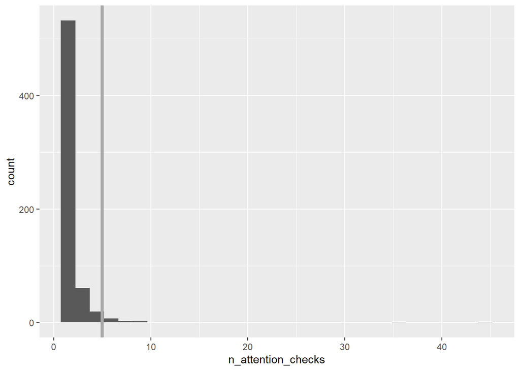

```r
library(ggplot2)
ggplot(d, aes(n_attention_checks)) + geom_histogram() +
    geom_vline(xintercept = 5, linetype = "solid",  color = "darkgrey", size = 1.5)
```

The x axis is the number of times a participant required to complete the attention check. The y axis shows he counts of those attempts. The grey line is the exlusion criteria we pre-determrined (i.e., Exclude any participant who needs more than 5 attempts).

We can remove participants based on that criteria:

```r
# get number of people who would be excluded from full sample without prior exclusions
atten_exclude<-sum(d_save$n_attention_checks >5)
# actually exclude from data
d <- d[d$n_attention_checks <= 5, ]
```

From this we can see that 14 participants were removed based on the attention check.

Next, we can look at the distribution of number of audio checks required for each participant:

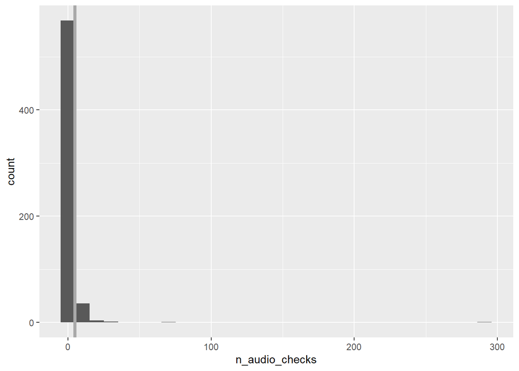

```r
library(ggplot2)
ggplot(d, aes(n_audio_checks)) + geom_histogram() +
    geom_vline(xintercept = 5, linetype = "solid",  color = "darkgrey", size = 1.5)
```

The x axis is the number of times a participant required to complete the audio check. The y axis shows he counts of those attempts. The grey line is the exlusion criteria we pre-determrined (i.e., Exclude any participant who needs more than 5 attempts).

We can remove participants based on that criteria:

```r
# get number of people who would be excluded from full sample without prior exclusions
audio_exclude<-sum(d_save$n_audio_checks >5)
# actually exclude from the data
d <- d[d$n_audio_checks <= 5, ]
```

From this we can see that 47 participants were removed based on the audio check.

We can have a look at the variables that could affect our other exclusion criteria:

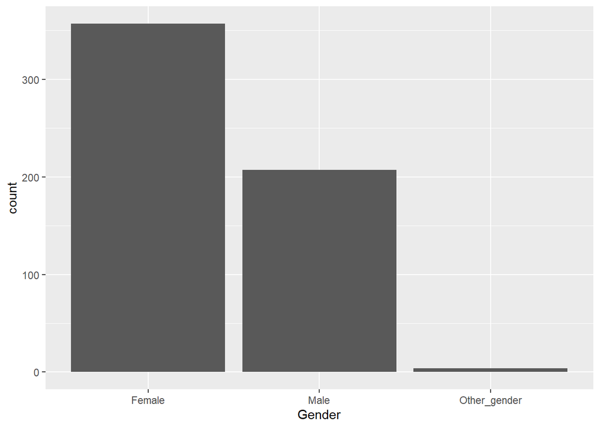

```r
ggplot(d, aes(gender)) + geom_bar() +
    xlab("Gender")
```

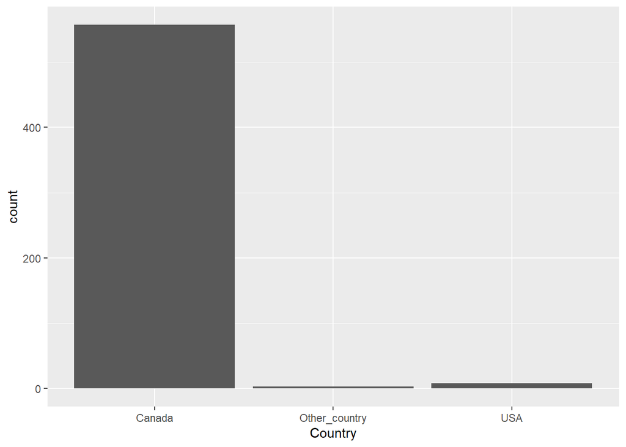

```r
ggplot(d, aes(country)) + geom_bar() +
    xlab("Country")
```

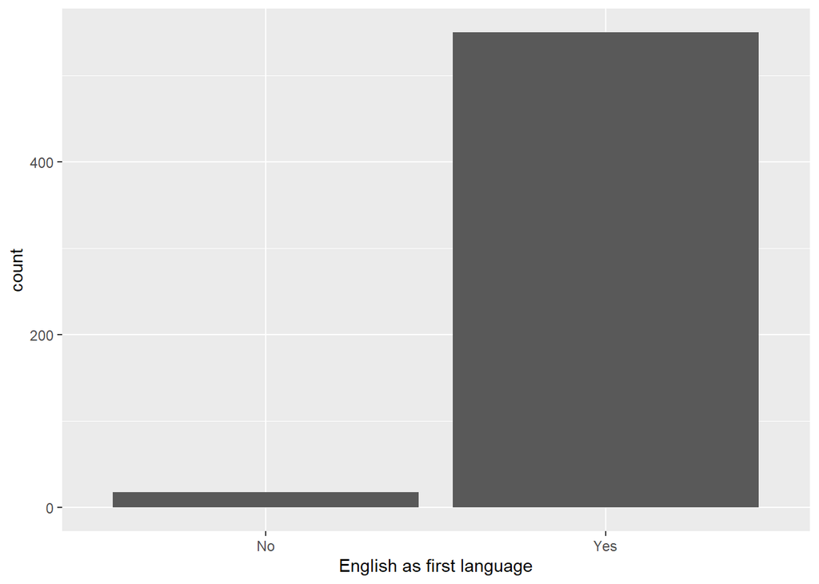

```r
ggplot(d, aes(eng_first)) + geom_bar() +
    xlab("English as first language")
```

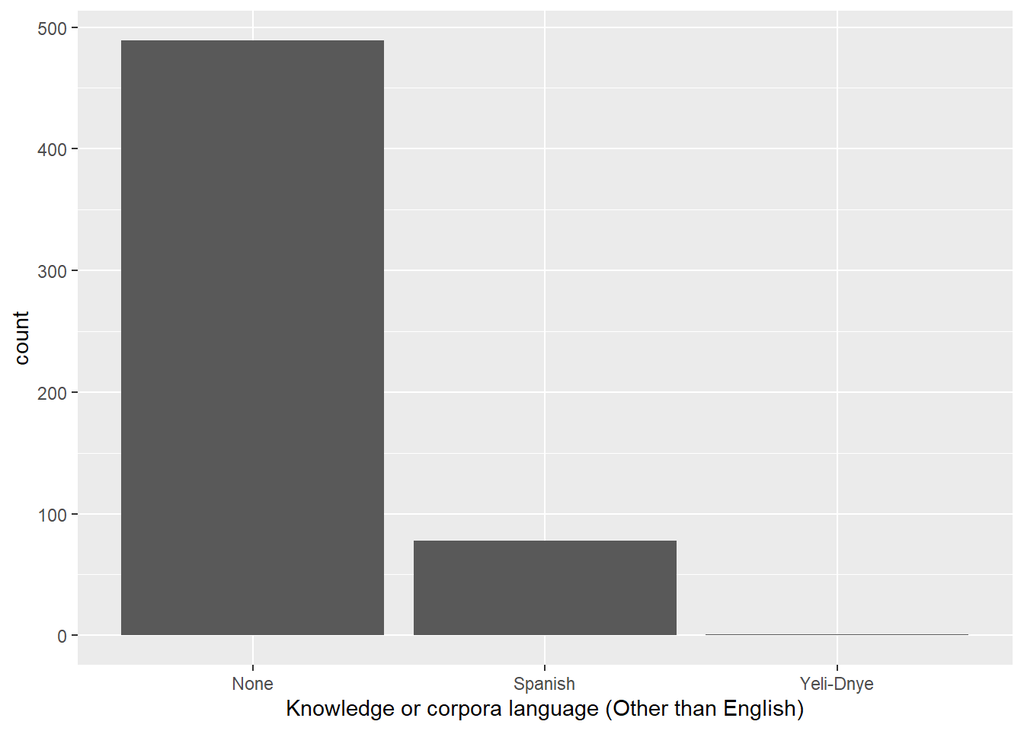

```r
ggplot(d, aes(know_corp_lang)) + geom_bar() +
    xlab("Knowledge or corpora language (Other than English)")
```

We’ll get rid of participants who specify a gender other than female or male, reside in a country other than Canada or the US, do not have English as a first language, have significant familiarity with the languages from Babble Cor other than English, or responded with the same response for any of the sex, language, or age question blocks:

```r
# get number of people who would be excluded from full sample without prior exclusions
gen_exclude<-length(d_save$gender)-sum(d_save$gender %in% c("Female", "Male"))
coun_exclude<-length(d_save$country)-sum(d_save$country %in% c("Canada", "USA"))
eng_exclude<-length(d_save$eng_first)-sum(d_save$eng_first=="Yes")
know_corp_exclude<-length(d_save$know_corp_lang)-sum(d_save$know_corp_lang=="None")
same_resp_exclude<-length(d_save$var_sex)-sum(d_save$var_sex>0 & d_save$var_lang>0 & d_save$var_age>0 )

# actually exclude from the sample
d <- d[d$gender %in% c("Female", "Male"), ]
d <- d[d$country %in% c("Canada", "USA"), ]
d <- d[d$eng_first == "Yes", ]
d <- d[d$know_corp_lang == "None", ]
d <- d[d$var_sex > 0 & d$var_lang > 0 & d$var_age > 0, ]
```

Number excluded based on:

- gender: 5
- country: 3
- English as a first language: 20
- knowing some of the corpus languages: 87
- giving the same response for all questions in a block: 7

The data now contains 460 observations (some participants were excluded for multiple reasons). Some of our sample’s demographic breakdown can be seen at the end of this document.

With the cleaning out of the way, let’s now have a look to see whether the data supports our hypotheses.

### Hypothesis 1: Participants will be able to identify the infant’s sex significantly above chance (50%)

Presumably, some participants will do well and some not well. Let’s plot all participant’s proportion of correct responses at determining the babies’ sex:

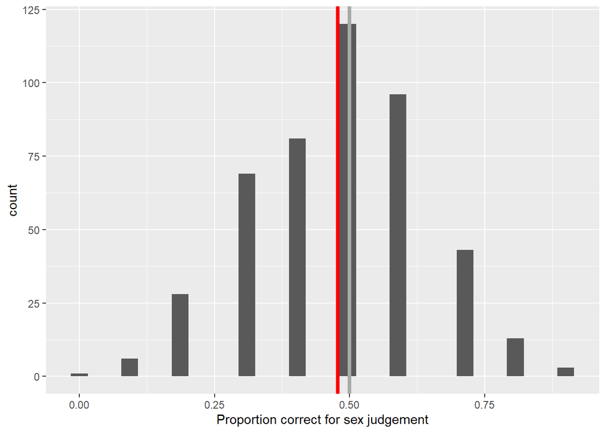

```r
ggplot(d, aes(p_cor_sex)) + geom_histogram() +
    geom_vline(xintercept = 0.5, linetype="solid",  color = "darkgrey", size=1.5) +
    geom_vline(xintercept = mean(d$p_cor_sex), linetype="solid",  color = "red", size=1.5) +
    xlab("Proportion correct for sex judgement")
```

The x axis is the proportion of correct responses for the sex question and the y axis is the number of responses.

As we can see, some people at the far left of the plot do terrible, scoring 0% correct. Some people do better, scoring quite well (80% correct).

However, the average proportion correct is 0.48(sd = 0.16) which is represented by the red vertical line.

The grey vertical line represents 0.50 (50%). This is how well we would expect people to do on average if they we’re just guessing or had no ability to discriminate between audio clips from male or female babies.

We would like to see the red line far to the right of the grey line. This would indicate that participants could discriminate between the sex of the babies in the clips better than chance. However, we see that participants are actually performing worse than chance.

For completeness, let run a one sample t-test that will test if the participants’ average of 0.48 is significantly different than 0.5:

```r
t.test(d$p_cor_sex, mu = 0.5)
```

```
##
##  One Sample t-test
##
## data:  d$p_cor_sex
## t = -2.9268, df = 459, p-value = 0.003595
## alternative hypothesis: true mean is not equal to 0.5
## 95 percent confidence interval:
##  0.4640277 0.4929288
## sample estimates:
## mean of x
## 0.4784783
```

```r
eff_size<-(mean(d$p_cor_sex)-0.5)/sd(d$p_cor_sex)
```

From this output we can see that the results are significant at the $\alpha$ = 0.01 level but in the wrong direction. This idicates that participants performed worse than what we would expect by chance. The cohen’s D effect size of this difference is -0.1364611.

### Hypothesis 2: Participants will be able to identify whether the infant is acquiring English or another language above chance (50%)

As with hypothesis 1, let’s have a look at the distribution of performance for the language hypothesis:

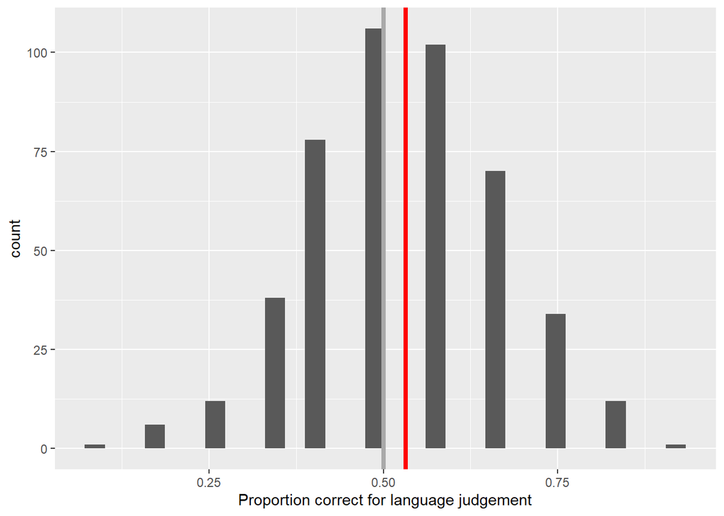

```r
library(ggplot2)

ggplot(d, aes(p_cor_lang)) + geom_histogram() +
    geom_vline(xintercept = 0.5, linetype = "solid",  color = "darkgrey", size = 1.5) +
    geom_vline(xintercept = mean(d$p_cor_lang), linetype="solid",  color = "red", size=1.5) +
    xlab("Proportion correct for language judgement")
```

The x axis is the proportion of correct responses for the language question and the y axis is the number of responses.

The average proportion correct is 0.53(sd = 0.14) which is represented by the red vertical line. Again, the grey vertical line represents 0.50 (50%).

Here participant’s are (numerically) performing better than chance.

Let’s run a one sample t-test to determine if participant’s are performing statistically better than chance:

```r
t.test(d$p_cor_lang, mu = 0.5)
```

```
##
##  One Sample t-test
##
## data:  d$p_cor_lang
## t = 4.9407, df = 459, p-value = 1.092e-06
## alternative hypothesis: true mean is not equal to 0.5
## 95 percent confidence interval:
##  0.5194206 0.5450722
## sample estimates:
## mean of x
## 0.5322464
```

```r
eff_size<-(mean(d$p_cor_lang)-0.5)/sd(d$p_cor_lang)
```

From this output we can see that the results are significant at the 0.01 level. For those unfamiliar with the scientific notation of the p value reported in the output above, the p value is 0.000001092315. This indicates that participants are able to discriminate between the language the babies are aquiring better than would be expected by chance. However the effect size is quite small with a cohen’s D = 0.2303633.

### Hypothesis 3: Participants will be able to identify the infant’s age range above chance (33%).

Let’s have a look at the distribution of performance for the age hypothesis:

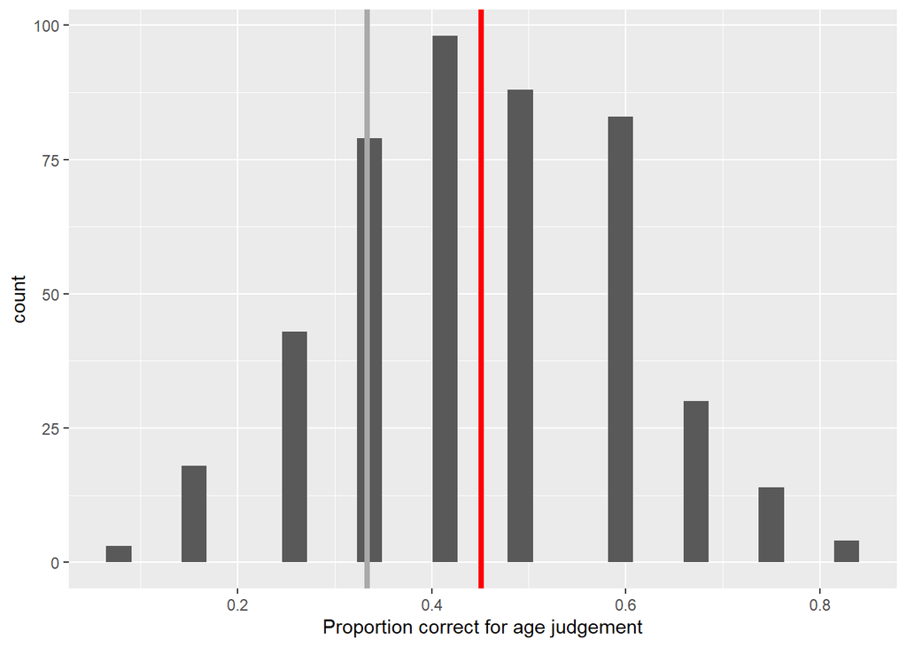

```r
library(ggplot2)

ggplot(d, aes(p_cor_age)) + geom_histogram() +
    geom_vline(xintercept = 1/3, linetype = "solid",  color = "darkgrey", size = 1.5) +
    geom_vline(xintercept = mean(d$p_cor_age), linetype="solid",  color = "red", size=1.5) +
    xlab("Proportion correct for age judgement")
```

The x axis is the proportion of correct responses for the age question and the y axis is the number of responses.

Let’s run a one sample t-test to determine if participant’s are performing statistically better than chance:

```r
t.test(d$p_cor_age, mu = 1/3)
```

```
##
##  One Sample t-test
##
## data:  d$p_cor_age
## t = 17.343, df = 459, p-value < 2.2e-16
## alternative hypothesis: true mean is not equal to 0.3333333
## 95 percent confidence interval:
##  0.4375835 0.4642281
## sample estimates:
## mean of x
## 0.4509058
```

```r
eff_size<-(mean(d$p_cor_age)-(1/3))/sd(d$p_cor_lang)
```

Given these significant results, that people were able to discriminate between babies age groups as well as the language the babies are aquiring, we have several follow up hypotheses.

### Demographic Breakdown

Below is some of the counts and descriptive statistics for our dataset

```r
library(plyr)
count(d, 'gender')
```

```
##   gender freq
## 1 Female  293
## 2   Male  167
```

```r
count(d, 'gender_text')
```

```
##   gender_text freq
## 1              393
## 2      female   34
## 3      Female   14
## 4     female     1
## 5        male    6
## 6        Male   11
## 7       male     1
```

```r
count(d, 'country')
```

```
##   country freq
## 1  Canada  455
## 2     USA    5
```

```r
count(d, 'country_text')
```

```
##   country_text freq
## 1               400
## 2       canada   14
## 3       Canada   41
## 4      Canada     2
## 5          usa    2
## 6          USA    1
```

```r
count(d, 'hearing') # no exclusion based on this?
```

```
##   hearing freq
## 1      No    3
## 2     Yes  457
```

```r
count(d, 'eng_first')
```

```
##   eng_first freq
## 1       Yes  460
```

```r
count(d, 'know_corp_lang')
```

```
##   know_corp_lang freq
## 1           None  460
```

```r
count(d, 'monolingual') # no exlusion based on this?
```

```
##   monolingual freq
## 1          No  167
## 2         Yes  293
```

```r
library(psych)
describe(d)
```

```
##                     vars   n     mean        sd   median  trimmed      mad
## subject_ID*            1 460   230.50    132.93   230.50   230.50   170.50
## p_cor_sex              2 460     0.48      0.16     0.50     0.48     0.15
## p_cor_lang             3 460     0.53      0.14     0.50     0.53     0.12
## p_cor_age              4 460     0.45      0.15     0.42     0.45     0.12
## time_mins              5 460    21.41    100.91    11.36    11.75     3.39
## fin_consent_mins       6 460     3.09     49.87     0.28     0.46     0.29
## consent_to_fin_mins    7 460    18.32     87.98    10.87    11.02     2.95
## max_RT_exp_trials      8 460 55217.96 157936.40 31720.58 36015.02 14290.26
## childcare              9 453     5.04     12.34     0.00     1.73     0.00
## caregiver             10 458     1.15      6.49     0.00     0.01     0.00
## age                   11 460    19.82      3.78    19.00    18.92     1.48
## gender*               12 460     1.36      0.48     1.00     1.33     0.00
## gender_text*          13 460     1.33      1.00     1.00     1.06     0.00
## country*              14 460     1.01      0.10     1.00     1.00     0.00
## country_text*         15 460     1.25      0.70     1.00     1.04     0.00
## hearing*              16 460     1.99      0.08     2.00     2.00     0.00
## eng_first*            17 460     1.00      0.00     1.00     1.00     0.00
## know_corp_lang*       18 460     1.00      0.00     1.00     1.00     0.00
## monolingual*          19 460     1.64      0.48     2.00     1.67     0.00
## n_attention_checks    20 460     1.51      0.83     1.00     1.34     0.00
## n_audio_checks        21 460     1.71      0.91     1.00     1.54     0.00
## var_sex               22 460     0.26      0.02     0.27     0.27     0.01
## var_lang              23 460     0.25      0.03     0.27     0.26     0.01
## var_age               24 460     0.55      0.14     0.57     0.55     0.17
##                          min        max      range   skew kurtosis      se
## subject_ID*             1.00     460.00     459.00   0.00    -1.21    6.20
## p_cor_sex               0.00       0.90       0.90  -0.10    -0.28    0.01
## p_cor_lang              0.08       0.92       0.83  -0.12    -0.07    0.01
## p_cor_age               0.08       0.83       0.75   0.04    -0.34    0.01
## time_mins               6.21    1532.91    1526.70  12.22   156.28    4.70
## fin_consent_mins        0.04    1069.80    1069.76  21.28   452.15    2.33
## consent_to_fin_mins     6.10    1532.62    1526.52  14.75   229.00    4.10
## max_RT_exp_trials   13752.69 3007993.15 2994240.46  15.52   272.84 7363.82
## childcare               0.00     120.00     120.00   4.02    21.87    0.58
## caregiver               0.00      90.00      90.00   8.71    92.99    0.30
## age                    17.00      47.00      30.00   3.83    16.97    0.18
## gender*                 1.00       2.00       1.00   0.57    -1.68    0.02
## gender_text*            1.00       7.00       6.00   3.69    13.55    0.05
## country*                1.00       2.00       1.00   9.40    86.62    0.00
## country_text*           1.00       6.00       5.00   3.02     9.84    0.03
## hearing*                1.00       2.00       1.00 -12.22   147.68    0.00
## eng_first*              1.00       1.00       0.00    NaN      NaN    0.00
## know_corp_lang*         1.00       1.00       0.00    NaN      NaN    0.00
## monolingual*            1.00       2.00       1.00  -0.57    -1.68    0.02
## n_attention_checks      1.00       5.00       4.00   1.81     3.31    0.04
## n_audio_checks          1.00       5.00       4.00   1.46     1.97    0.04
## var_sex                 0.10       0.28       0.18  -3.55    17.24    0.00
## var_lang                0.08       0.27       0.19  -3.20    13.06    0.00
## var_age                 0.15       0.91       0.76  -0.39     0.12    0.01
```